# Bonus Content

Cleo Falvey & Filip Stefanovic

7/31/2020

## A few extra fun things that I thought might take up too much time but are still useful to learn to do.

# Day One

### Making a Shapiro Wilk Test for GRE scores in grad school applications

```r
library(tidyverse) # call library you need - tidyverse includes readr
grad_school <- read_csv("grad_school.csv") # read in necessary file about graduate school
```

To plot a histogram of, for example, the GRE scores of the applicants, you could run the command below. We use the **$** operator to reference the columns of the dataset by name.

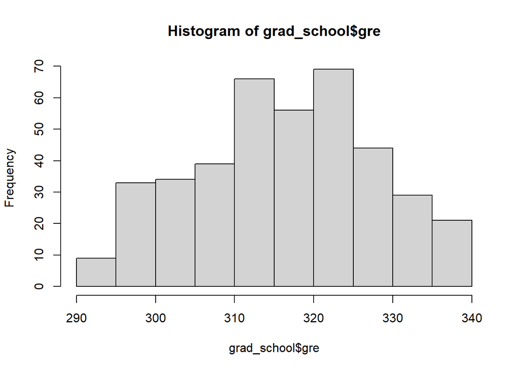

```r
hist(grad_school$gre) # makes a histogram of GRE scores
```

Looking at the dataset, we can see that the GRE scores do seem to show a normal distribution. In fact, the GRE is designed to have a normal distribution (some people do quite poorly, some people do quite well, and most people do right about the middle). How would we test whether this data set is normal?

Answer: Use a Shapiro-Wilk test!

```r
shapiro.test(grad_school$gre)
```

```
##
##  Shapiro-Wilk normality test
##
## data:  grad_school$gre
## W = 0.98572, p-value = 0.0005625
```

Here’s the results of the Shapiro-Wilk test. If you’ve taken a statistics class, you might remember that the threshold for significance is .05. This data seems to fail the Shapiro-Wilk test. It certainly does deviate from the normal distribution!

Remember when we plot normal distributions that it has two parameters, mean and standard deviation.

```r
mean(grad_school$gre) # get mean of grad school gre scores
```

```
## [1] 316.8075
```

```r
sd(grad_school$gre) # get standard deviation of grad school gre scores
```

```
## [1] 11.47365
```

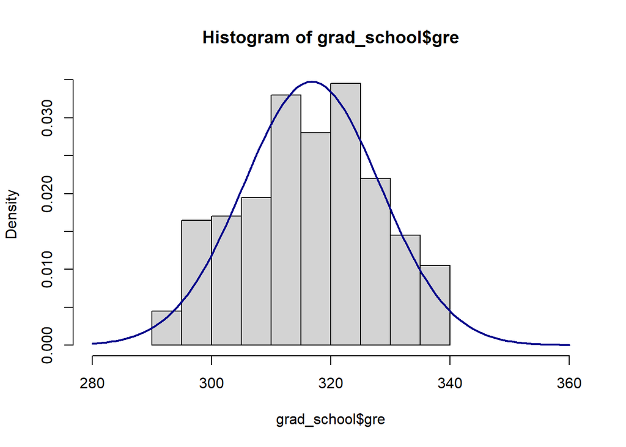

```r
hist(grad_school$gre, freq=F, xlim=c(280,360)) # relative frequency histogram with custom x axis limits
curve(dnorm(x, mean=316.8075, sd=11.47365), add=TRUE, col="darkblue", lwd=2) # curves a normal distribution atop a frequency histogram
```

# Day Two:

### Built-in Datasets

R has built-in datasets that many people use, especially when trying to provide a reproducible example (reprex) when asking for help or debugging. These datasets can be found using the *data()* function.

## Pivot Longer

```r
spotify <- read_csv("spotify.csv") #reads in spotify data
short_spotify <- head(spotify) # makes a shorter version of spotify
```

What if we wanted to have the data be longer than it is? i.e., we had just ONE column of numbers, and another column showed which value it was?

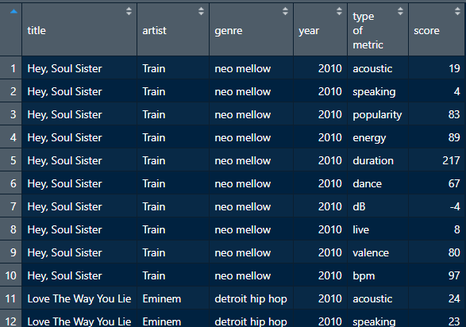

```r
knitr::include_graphics("long_data.png")
```

Enter *pivot_longer()* from dplyr. We use the pipe! In pivot longer, the first argument is the names of all the columns that we want to be pivoting. The next thing is it creates key-value pairs, which you need to rename (or else it’ll just call them “key” and “value”).

```r
long_spotify <- short_spotify %>%
  pivot_longer(cols=c("popularity","duration","dB","bpm"),names_to="type_of_metric", values_to="score")

head(long_spotify)
```

```
## # A tibble: 6 x 6
##   title                artist genre            year type_of_metric score
##   <chr>                <chr>  <chr>           <dbl> <chr>          <dbl>
## 1 Hey, Soul Sister     Train  neo mellow       2010 popularity        83
## 2 Hey, Soul Sister     Train  neo mellow       2010 duration         217
## 3 Hey, Soul Sister     Train  neo mellow       2010 dB                -4
## 4 Hey, Soul Sister     Train  neo mellow       2010 bpm               97
## 5 Love The Way You Lie Eminem detroit hip hop  2010 popularity        82
## 6 Love The Way You Lie Eminem detroit hip hop  2010 duration         263
```

## Pivot Wider

In *pivot_wider()*, the same concept is utilized except. Below, I remake (and thus undo my long pivot) to create the same data frame with my long spotify data.

```r
short_spotify_again <- long_spotify %>%
  pivot_wider(names_from = "type_of_metric", values_from = "score")

head(short_spotify_again)
```

```
## # A tibble: 6 x 8
##   title            artist      genre        year popularity duration    dB   bpm
##   <chr>            <chr>       <chr>       <dbl>      <dbl>    <dbl> <dbl> <dbl>
## 1 Hey, Soul Sister Train       neo mellow   2010         83      217    -4    97
## 2 Love The Way Yo~ Eminem      detroit hi~  2010         82      263    -5    87
## 3 TiK ToK          Kesha       dance pop    2010         80      200    -3   120
## 4 Bad Romance      Lady Gaga   dance pop    2010         79      295    -4   119
## 5 Just the Way Yo~ Bruno Mars  pop          2010         78      221    -5   109
## 6 Baby             Justin Bie~ canadian p~  2010         77      214    -5    65
```

Pivoting is really useful because it changes the shape of data - sometimes certain functions need data to be structured a certain way.

# Day 3: Iris Analyses

Here is a sample workflow for the Iris dataset we’ll be working with on Day 3.

### Reading in Data

```r
iris <- read_csv("Iris.csv")
```

### Petal Length, Petal Width

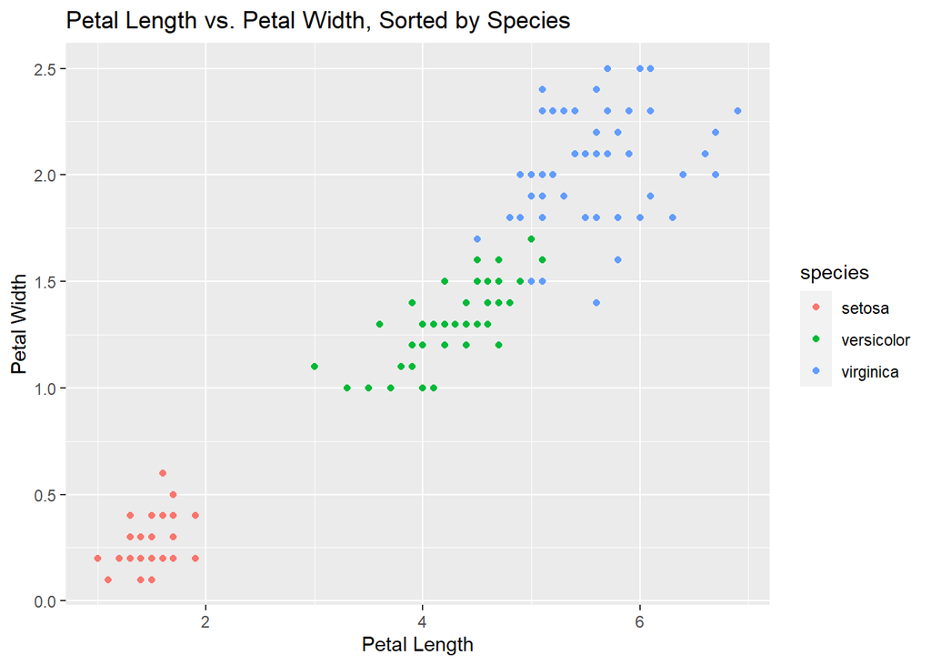

```r
ggplot(iris, aes(x=petal_length, y=petal_width, color=species)) +
  geom_point() +
  labs(x="Petal Length", y="Petal Width", title="Petal Length vs. Petal Width, Sorted by Species")
```

A boxplot of sepal length by species is below.

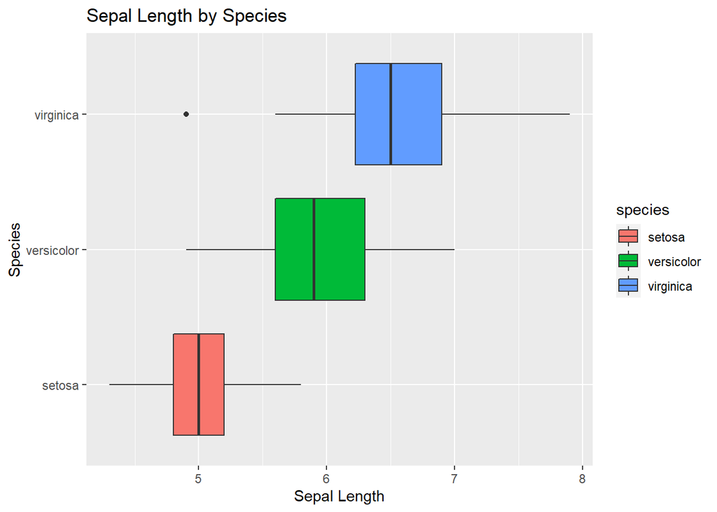

```r
ggplot(iris, aes(x=sepal_length, group=species, y=species, fill=species)) +
  geom_boxplot() +
  labs(x="Sepal Length", y="Species", title="Sepal Length by Species")
```

We can see from the boxplot and scatterplot that virginica is consistently the largest flower. One of the things that we might consider is examining the ratio of flower sizes. Sometimes that changes things!

To do this we are going to use dplyr & ggplot2.

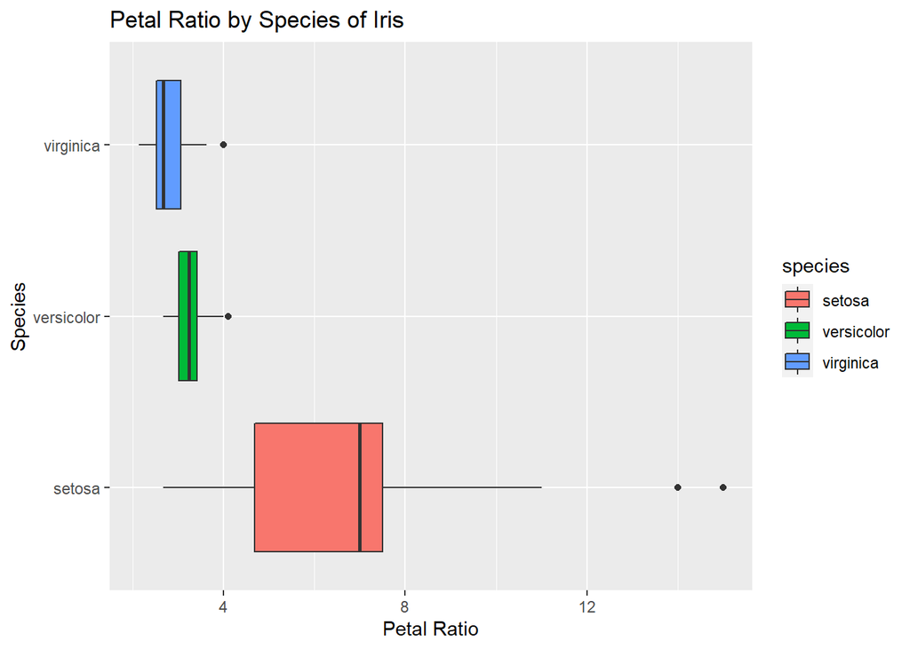

```r
iris %>%
  mutate(petal_ratio = petal_length / petal_width) %>%
  ggplot(aes(x=petal_ratio, y=species, group=species, fill=species)) +
  geom_boxplot() +
  labs(x="Petal Ratio", y="Species", title="Petal Ratio by Species of Iris")
```

We can see that virginica is clearly the largest flower but has a different (smaller) petal length to petal width ratio than the other flowers.

These are just a few ideas I wanted to come prepared with to the R workshop. Feel free to come up with your own!